# HSC Survey Results

# Scots Bay Survey # 6 Results from 19/07/2026

## Survey Details

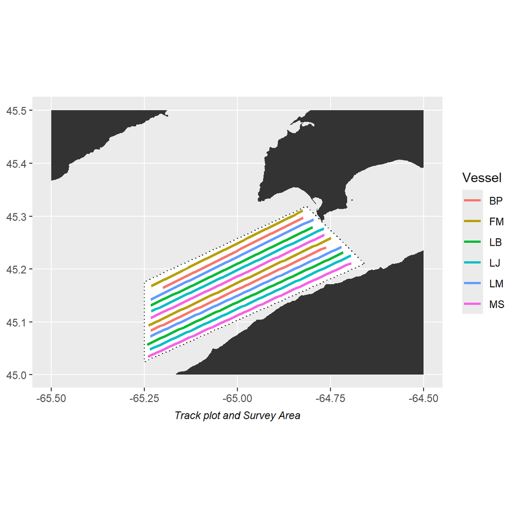

6 commercial purse seiners conducted this fishing survey on 19/07/2026 starting at 21:00:00, which was 4.23 hour after high tide.

All vessels ran two transects each in the Main Survey Box.

There was a plankton tow and replicate conducted and CTD cast by Lady Janice II.

No tags were applied during this survey.

Samples were obtained for target strength estimation.

### Tides Tables

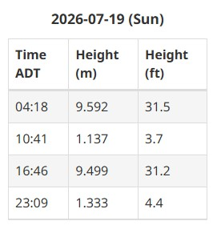

[figure not shown]

Tide Schedule for Margaretsville NS, Station #315m Source: www.waterlevels.gc.ca

### Acoustic Equipment

Each vessel was equipped with a Simrad ES38-18/200-18C combi (2-in-1) transducer prior to the survey that contains a 38kHz split beam and 200 kHz single beam transducer. Data was logged to the computer hard-drive for post-processing. All participating boats were calibrated on 38kHz before the survey.

## Survey Results

### Main Results

The results are subject to change as DFO will re-evaluate data editing, area estimation and apply a target strength.

**Preliminary biomass prediction for Scots Bay using standardized parallel transects is 21,513mt, and with turnover applied 18,616mt.**

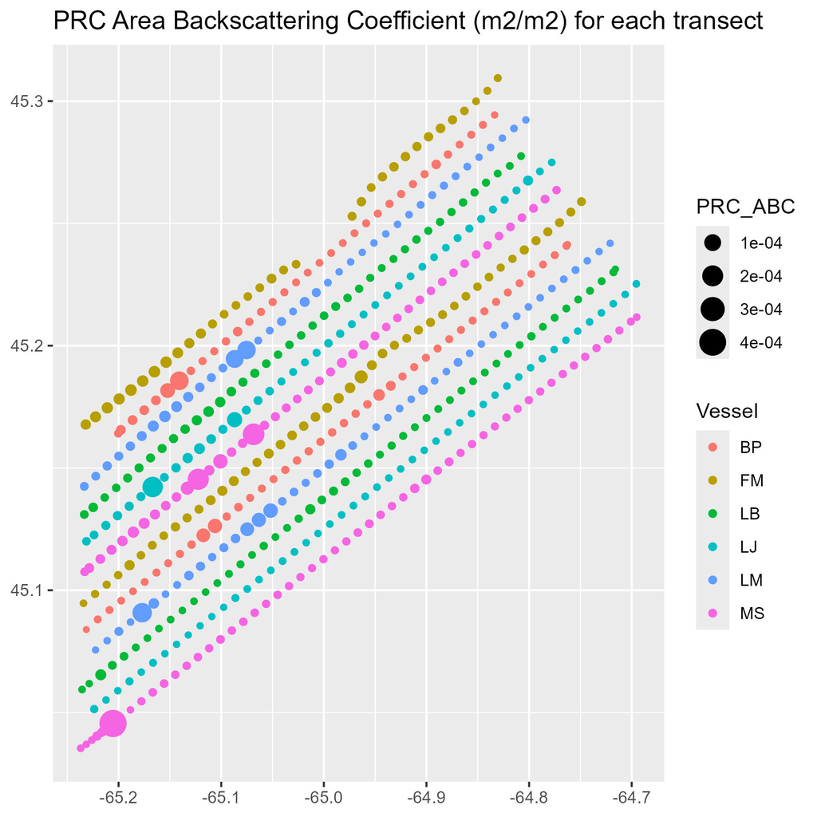

### Transect Details

Table 1: Transect Details

| Vessel | Transect # | Date/Time Start | Date/Time End | Start Lon | Start Lat | End Lon | End Lat | Location | Distance (km) | Speed |
| --- | --- | --- | --- | --- | --- | --- | --- | --- | --- | --- |
| BP | T01 | 2026-07-19 20:09:35 | 2026-07-19 22:55:16 | -65.233 | 45.083 | -64.763 | 45.241 | SB | 41.24 | 8.06 |
| BP | T02 | 2026-07-19 23:22:19 | 2026-07-20 01:18:28 | -64.824 | 45.297 | -65.200 | 45.164 | SB | 33.10 | 9.23 |
| FM | T01 | 2026-07-19 21:50:49 | 2026-07-20 00:40:42 | -65.239 | 45.093 | -64.749 | 45.259 | SB | 43.35 | 8.27 |
| FM | T02 | 2026-07-20 01:14:55 | 2026-07-20 03:39:16 | -64.825 | 45.310 | -65.232 | 45.168 | SB | 36.30 | 8.15 |
| LB | T01 | 2026-07-19 19:49:29 | 2026-07-19 23:34:44 | -65.242 | 45.057 | -64.716 | 45.231 | SB | 47.21 | 6.79 |
| LB | T02 | 2026-07-20 00:15:07 | 2026-07-20 03:24:04 | -64.798 | 45.279 | -65.233 | 45.131 | SB | 38.55 | 6.61 |
| LJ | T01 | 2026-07-19 20:46:58 | 2026-07-19 23:50:40 | -65.235 | 45.048 | -64.695 | 45.226 | SB | 47.03 | 8.29 |
| LJ | T02 | 2026-07-20 00:18:39 | 2026-07-20 03:07:21 | -64.768 | 45.277 | -65.231 | 45.120 | SB | 40.49 | 7.77 |
| LM | T01 | 2026-07-19 20:39:15 | 2026-07-19 23:39:32 | -65.234 | 45.073 | -64.721 | 45.242 | SB | 44.92 | 8.07 |
| LM | T02 | 2026-07-20 00:10:55 | 2026-07-20 02:45:26 | -64.797 | 45.294 | -65.234 | 45.142 | SB | 38.61 | 8.10 |
| MS | T01 | 2026-07-19 20:25:43 | 2026-07-20 00:36:22 | -65.240 | 45.034 | -64.695 | 45.212 | SB | 53.09 | 6.86 |
| MS | T02 | 2026-07-20 01:06:08 | 2026-07-20 04:03:21 | -64.767 | 45.265 | -65.233 | 45.108 | SB | 43.00 | 7.86 |

### Survey Summary

Table 2: Acoustic Survey Results

| Vessel | Transect No. | Target Strength (db/kg) | Mean Sa (/m2) | Biomass Density (kg/m2) |
| --- | --- | --- | --- | --- |
| MS | T02 | -35.5 | -47.225 | 0.067 |
| MS | T01 | -35.5 | -47.755 | 0.059 |
| LM | T02 | -35.5 | -49.700 | 0.038 |
| LJ | T02 | -35.5 | -49.907 | 0.036 |
| LM | T01 | -35.5 | -50.084 | 0.035 |
| BP | T02 | -35.5 | -50.157 | 0.034 |
| FM | T02 | -35.5 | -50.275 | 0.033 |
| FM | T01 | -35.5 | -51.673 | 0.024 |
| BP | T01 | -35.5 | -52.959 | 0.018 |
| LB | T02 | -35.5 | -53.617 | 0.015 |
| LB | T01 | -35.5 | -56.347 | 0.008 |
| LJ | T01 | -35.5 | -60.814 | 0.003 |

Note:  
Transects are listed from greatest to least backscatter.

Table 3: Survey Summary Table

| Layer | Target Strength | Area (km2) | Mean Sa | Density (kg/m2) | Biomass (tons) | Percent Area | Percent Biomass | Standard Error (tons) | Standard Error (%) |
| --- | --- | --- | --- | --- | --- | --- | --- | --- | --- |
| Main Box | -35.5 | 690.2649 | -50.5632 | 0.031 | 21,512.88 | 100 | 100 | 3,798.07 | 17.65 |

### Greatest Biomass Densities

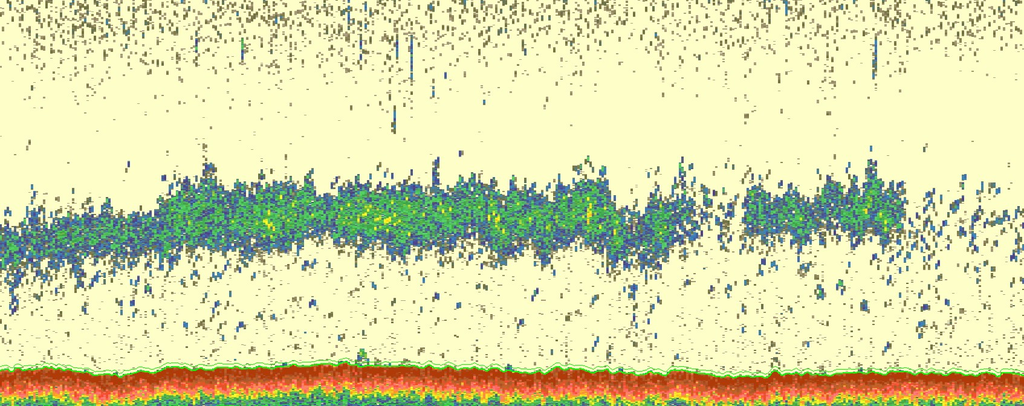

A snip from the transect with the greatest biomass density (kg/m2)

The single point with the largest biomass density (kg/m2) was recorded by **MS**, at the following location:

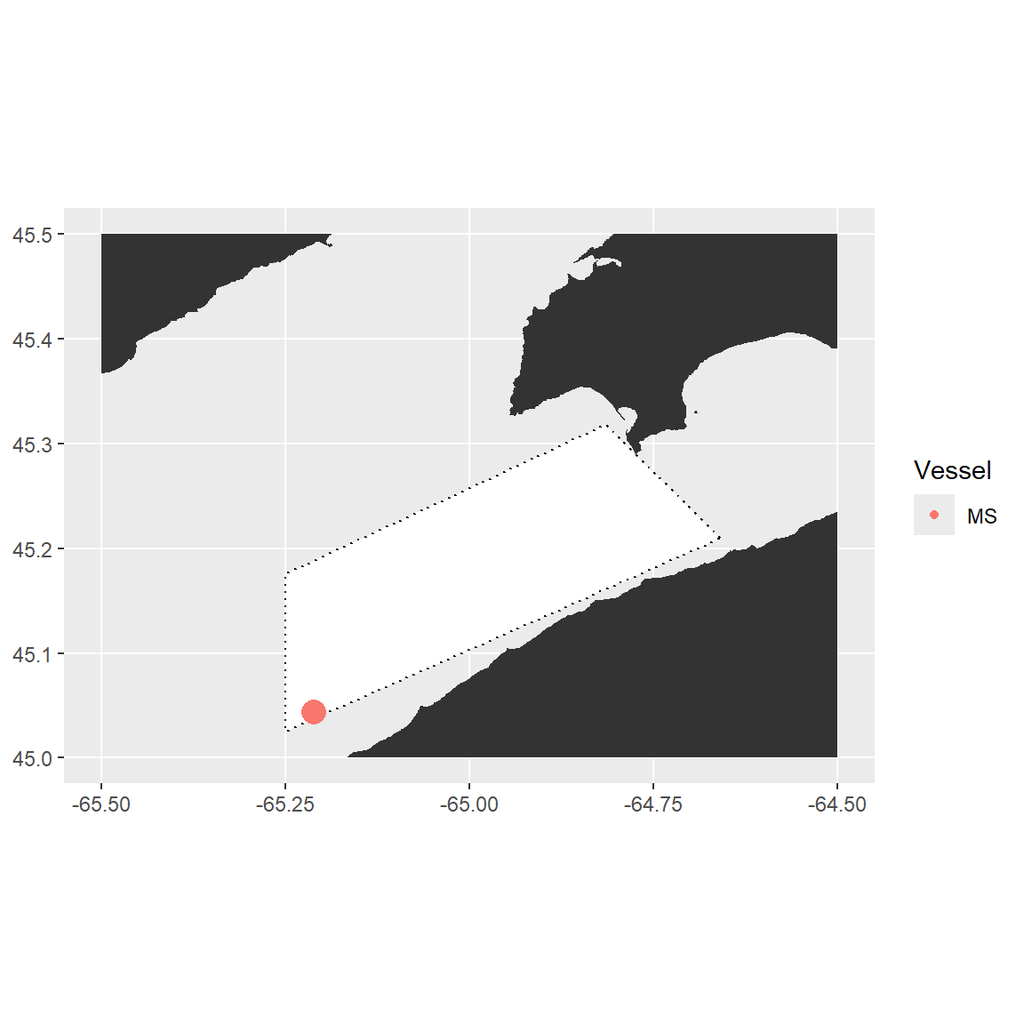

The transect with the greatest average biomass density (kg/m2) was recorded by **MS**, at the following location:

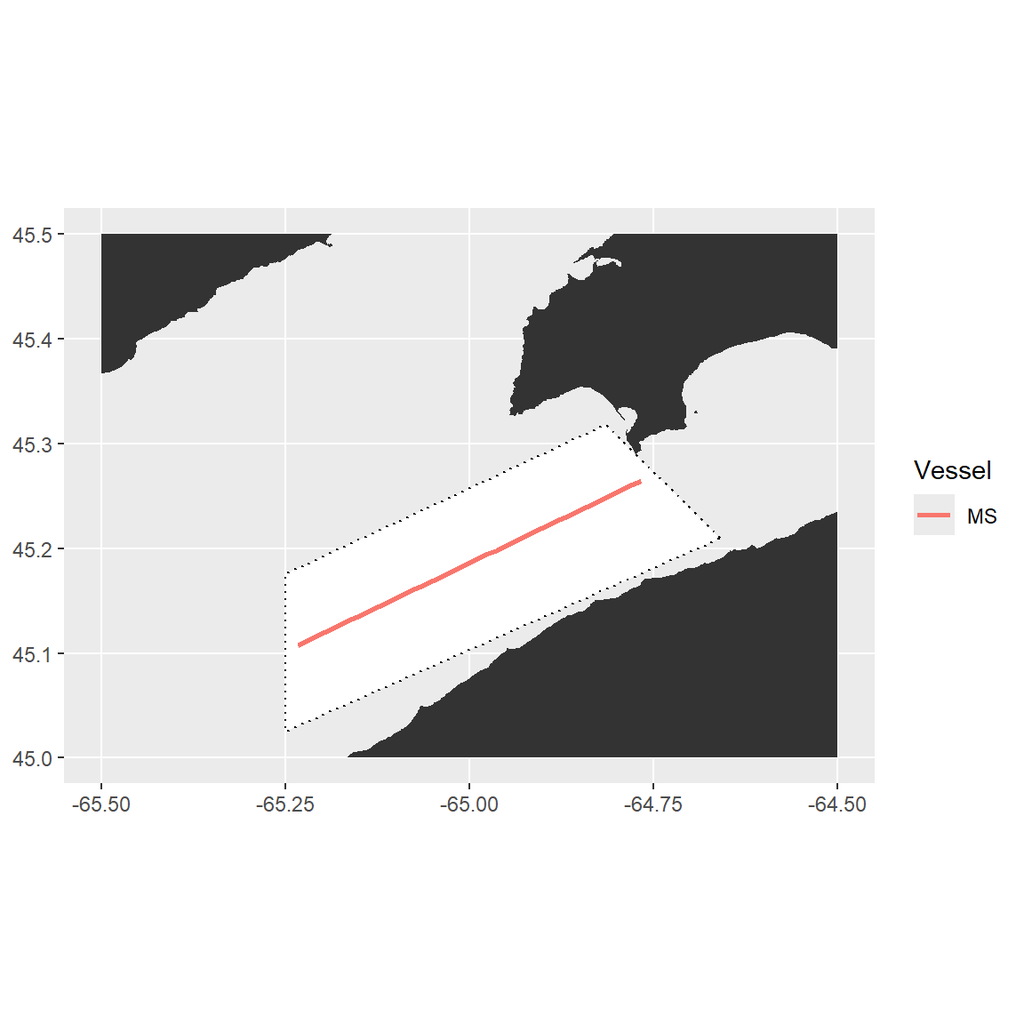

### Annual Summaries

This table does not include the biomass from adhoc surveys.

Table 4: Annual Comparison Table

| Ground | Survey Number | Current Year Survey Date | Current Year HSC Estimate | Current Year HSC Turnover Adjusted | Previous Year Survey Date | Previous Year HSC Estimate | Previous Year HSC Turnover Adjusted | Previous Year DFO Estimate | Previous Year DFO Turnover Adjusted |
| --- | --- | --- | --- | --- | --- | --- | --- | --- | --- |
| Scots Bay | 1 | 2026-05-10 | 29,384.00 | 29,384 | 2025-05-06 | 12,306 | 12,306 | NA | NA |
| Scots Bay | 2 | 2026-05-24 | 61,138.00 | 57,169 | 2025-05-20 | 120,045 | 118,023 | NA | NA |
| Scots Bay | 3 | 2026-06-07 | 48,291.00 | 39,929 | 2025-06-03 | 123,037 | 109,821 | NA | NA |
| Scots Bay | 4 | 2026-06-21 | 44,217.00 | 37,478 | 2025-06-16 | 14,184 | 0 | NA | NA |
| Scots Bay | 5 | 2026-07-05 | 20,280.02 | 14,137 | 2025-06-30 | 15,789 | 11,509 | NA | NA |
| Scots Bay | 6 | 2026-07-19 | 21,512.88 | 18,616 | 2025-07-14 | 7,114 | 5,137 | NA | NA |
| Scots Bay | 7 | NA | NA | NA | 2025-07-28 | 7,573 | 6,612 | NA | NA |
| Scots Bay | 8 | NA | NA | NA | 2025-08-11 | 5,164 | 4,916 | NA | NA |
| Scots Bay | 9 | NA | NA | NA | 2025-08-26 | 6,675 | 5,948 | NA | NA |
| Scots Bay | 10 | NA | NA | NA | 2025-09-08 | 4,180 | 3,169 | NA | NA |
| Scots Bay | 11 | NA | NA | NA | 2025-09-21 | 11,201 | 10,471 | NA | NA |

Table 5: Annual Summary Table

| Year | Ground | HSC Estimate | HSC Turnover Adjusted | DFO Estimate | DFO Turnover Adjusted |
| --- | --- | --- | --- | --- | --- |
| 2025 | Scots Bay | 327,268.0 | 287,912 | NA | NA |
| 2026 | Scots Bay | 224,822.9 | 196,713 | NA | NA |

## Vessel Performance

### Speed

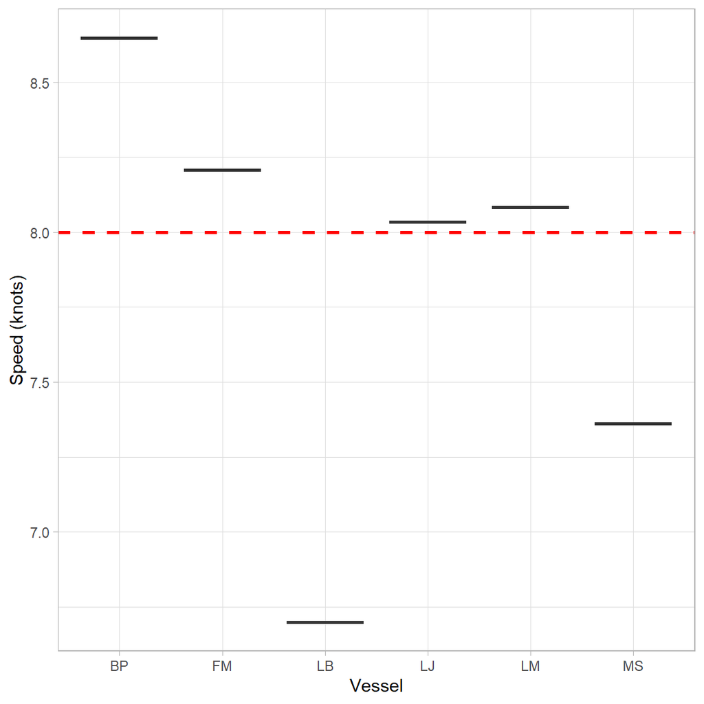

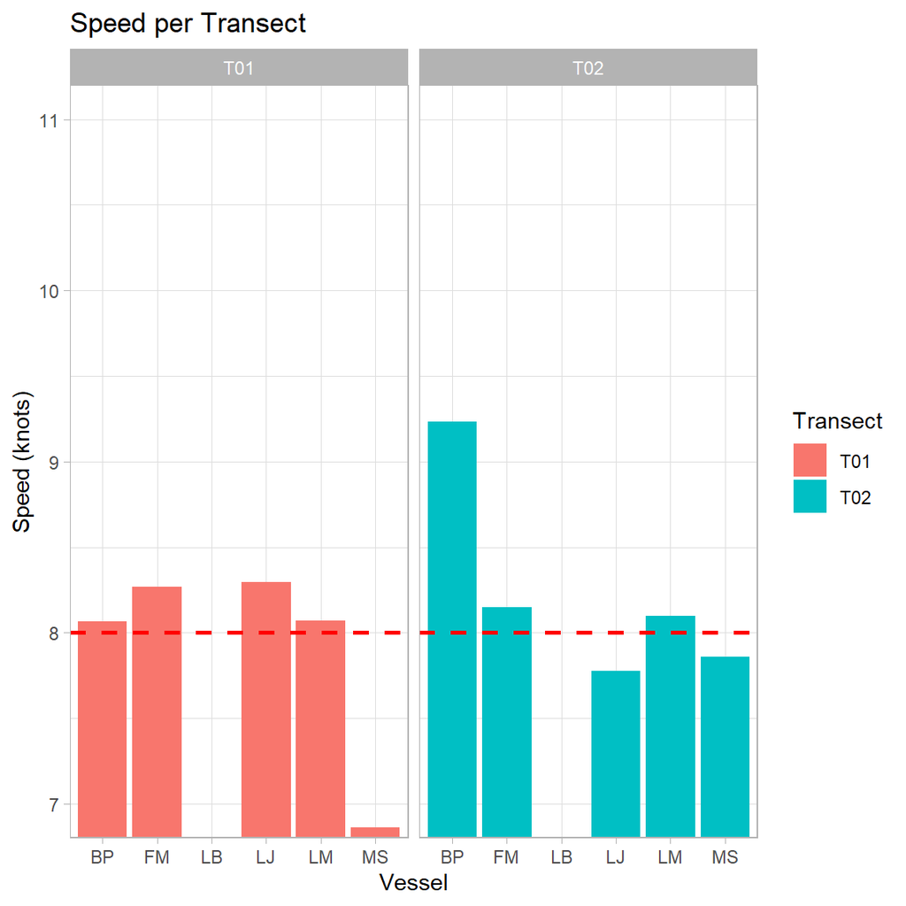

The vessels performed well and the average vessel speed was 7.84 which is below the requirements of 8 knots.

The speed for each transect are rudimentary and are calculated based on distance. If a significant amount of distance is cut, the speed will appear slower.

### Distance

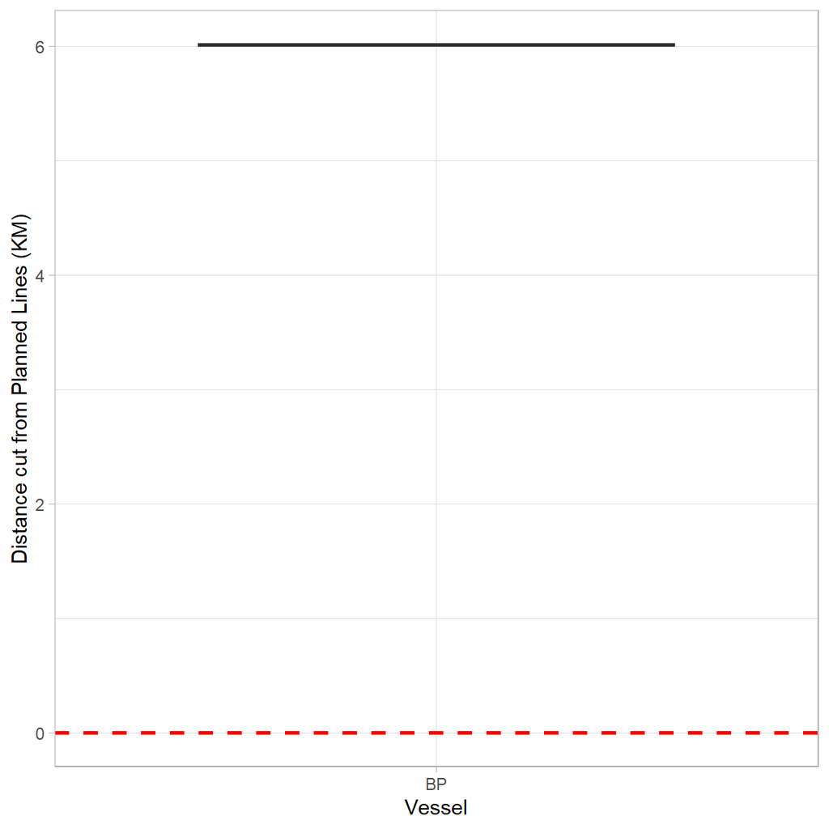

More than 2km of distance was cut from the planned lines; vessels are reminded to complete their assigned lines straight and without deviating or cutting corners short.